# SLX Contra Simple Regression

[output not shown]

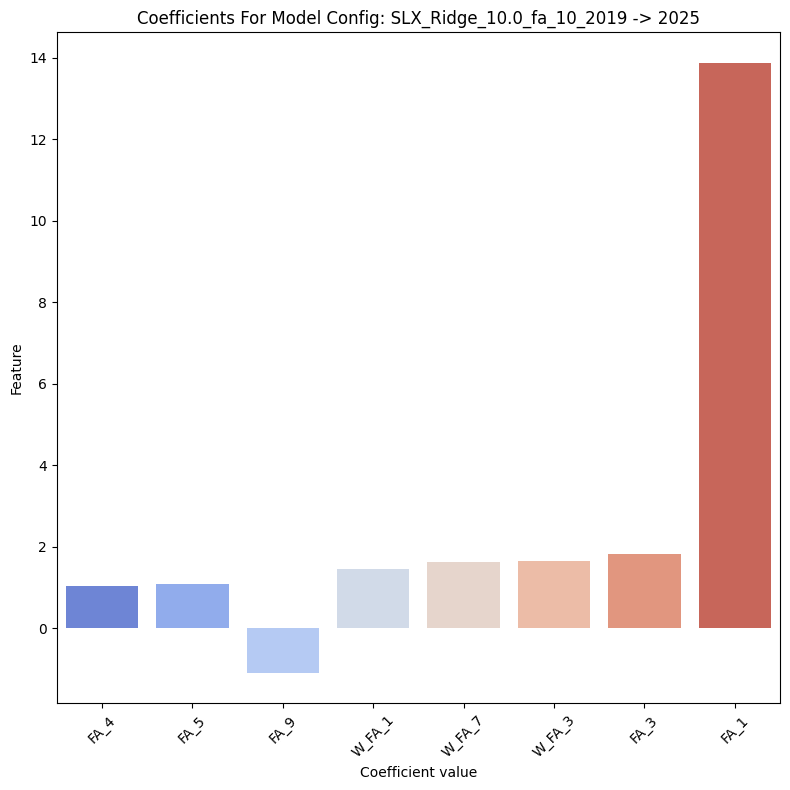

[output not shown]

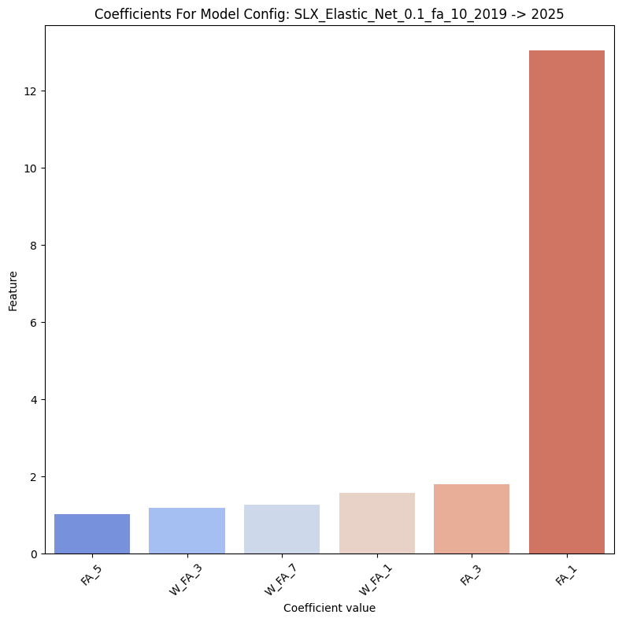

[output not shown]

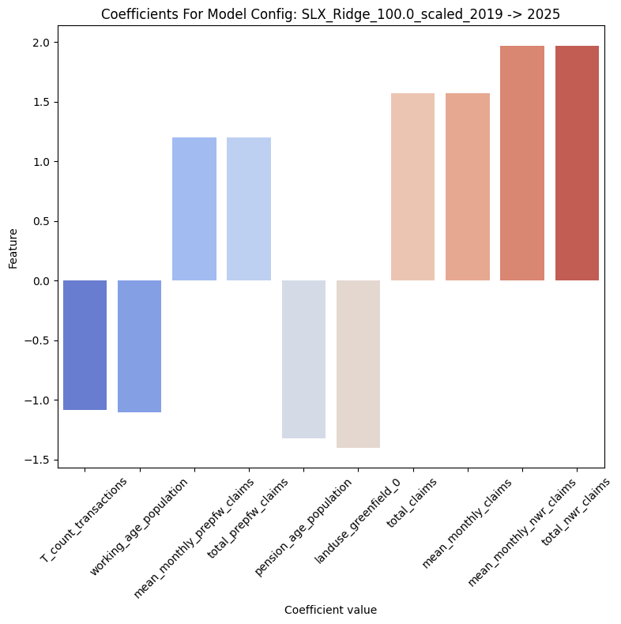

[output not shown]

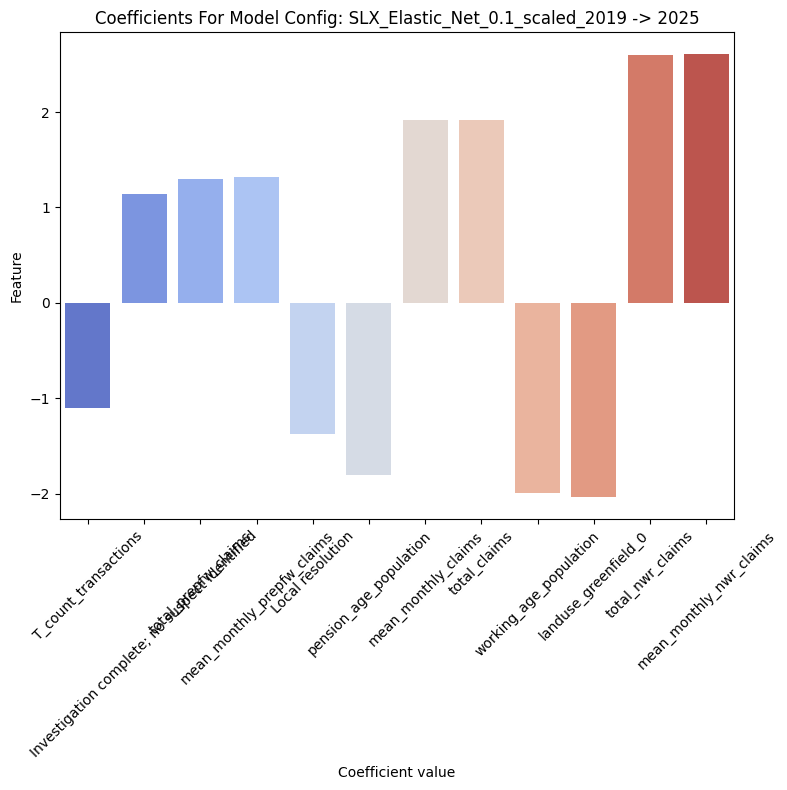

[output not shown]

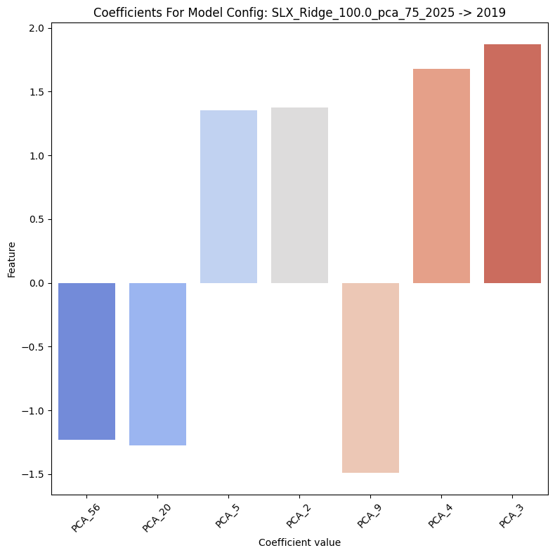

[output not shown]

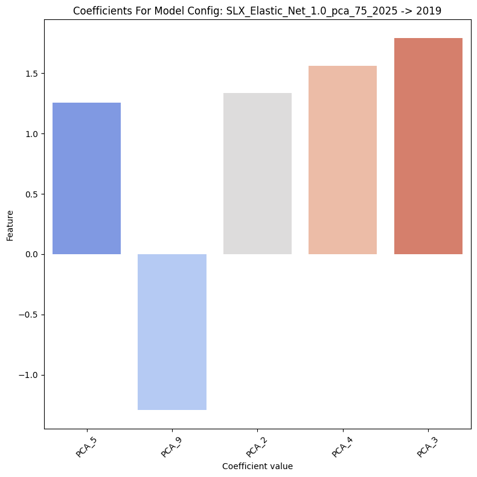

[output not shown]

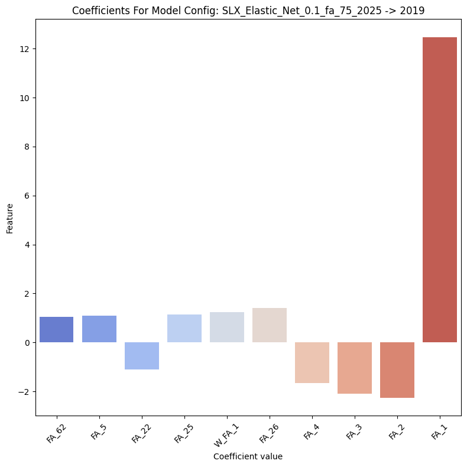

```python
# Loop through unique models
for model_id in top_coefs['model_id'].unique():
    subset = top_coefs[top_coefs['model_id'] == model_id].copy()

    # Sort features by validation coefficient magnitude
    subset['abs_val'] = subset['validation_value'].abs()
    subset = subset.sort_values('abs_val', ascending=True)

    subset = subset[subset['validation_value'].abs() >= 1]

    plt.figure(figsize=(8, 8))
    sns.barplot(
        x='feature_name',
        y='validation_value',
        data=subset,
        palette='coolwarm'
    )

    plt.title(f'Coefficients For Model Config: {model_id}', fontsize=12)
    plt.xlabel('Coefficient value')
    plt.xticks(rotation=45)
    plt.ylabel('Feature')
    plt.tight_layout()
    plt.show()
```

Patterns repeated here seem identical to the previous sections except for here some PCA appears which tend to follow the scaled datasets feature coeff distributions as seen before. Also, the firs Ridge and Elastic Net SLX models do make use of some spatially weighted features which is good to see.

With this in mind it seems even more pressing to investigate factor loadings on FA.

### Factor Loadings

```python
fa_10 = FactorAnalysis(n_components=10, random_state=RANDOM_STATE)
fa_75 = FactorAnalysis(n_components=75, random_state=RANDOM_STATE)

# 2019
X_scaled_2019 = StandardScaler().fit_transform(X_2019)
X_fa_10_2019 = fa_10.fit_transform(X_scaled_2019)
X_fa_75_2019 = fa_75.fit_transform(X_scaled_2019)

loadings_10 = pd.DataFrame(fa_10.components_.T, index=list(data_2019.columns), columns=[f'Factor {i+1}' for i in range(10)])
loadings_10.sort_values(by='Factor 1', ascending=False).head(5)
```

|  | Factor 1 | Factor 2 | Factor 3 | Factor 4 | Factor 5 | Factor 6 | Factor 7 | Factor 8 | Factor 9 | Factor 10 |
| --- | --- | --- | --- | --- | --- | --- | --- | --- | --- | --- |
| mean_monthly_claims | 1.000000 | 7.078906e-10 | -6.210401e-11 | -1.218296e-11 | -2.428272e-11 | 2.929183e-11 | 2.523265e-12 | -1.670039e-12 | 4.993575e-12 | 1.852506e-12 |
| total_claims | 1.000000 | 7.078906e-10 | -6.210400e-11 | -1.218295e-11 | -2.428268e-11 | 2.929167e-11 | 2.523280e-12 | -1.670075e-12 | 4.993549e-12 | 1.852456e-12 |
| mean_monthly_nwr_claims | 0.976340 | -1.284782e-01 | 4.917443e-02 | 2.377207e-02 | -3.362803e-03 | 7.115196e-02 | 2.187364e-03 | -1.889377e-02 | 1.568441e-02 | 3.731041e-02 |
| total_nwr_claims | 0.976340 | -1.284782e-01 | 4.917443e-02 | 2.377207e-02 | -3.362803e-03 | 7.115196e-02 | 2.187364e-03 | -1.889377e-02 | 1.568441e-02 | 3.731041e-02 |
| total_prepfw_claims | 0.942004 | -1.135636e-02 | 1.094668e-02 | 2.726589e-02 | -6.852344e-03 | 2.491714e-02 | -2.451015e-03 | -2.995669e-02 | 2.971449e-02 | 2.139409e-02 |

```python
loadings_75 = pd.DataFrame(fa_75.components_.T, index=list(data_2019.columns), columns=[f'Factor {i+1}' for i in range(75)])
loadings_75.sort_values(by='Factor 1', ascending=False).head(5)
```

|  | Factor 1 | Factor 2 | Factor 3 | Factor 4 | Factor 5 | Factor 6 | Factor 7 | Factor 8 | Factor 9 | Factor 10 | ... | Factor 66 | Factor 67 | Factor 68 | Factor 69 | Factor 70 | Factor 71 | Factor 72 | Factor 73 | Factor 74 | Factor 75 |
| --- | --- | --- | --- | --- | --- | --- | --- | --- | --- | --- | --- | --- | --- | --- | --- | --- | --- | --- | --- | --- | --- |
| mean_monthly_claims | 0.990917 | 0.004902 | -0.114323 | -0.070632 | 7.947670e-09 | -7.409870e-10 | 2.963962e-10 | 3.067297e-10 | 2.509453e-10 | 4.707043e-11 | ... | 2.233153e-13 | 2.198842e-13 | 1.385088e-13 | -1.707941e-13 | -5.895871e-13 | -4.463741e-13 | 4.010580e-14 | -4.078186e-13 | 1.313353e-14 | 1.831538e-13 |
| total_claims | 0.990917 | 0.004902 | -0.114323 | -0.070632 | 7.947670e-09 | -7.409871e-10 | 2.963962e-10 | 3.067296e-10 | 2.509450e-10 | 4.707054e-11 | ... | 2.232006e-13 | 2.198350e-13 | 1.385551e-13 | -1.709192e-13 | -5.895265e-13 | -4.461664e-13 | 4.002217e-14 | -4.077655e-13 | 1.323556e-14 | 1.830579e-13 |
| mean_monthly_prepfw_claims | 0.958043 | -0.122927 | -0.090883 | 0.242453 | -5.124080e-09 | 6.361601e-10 | 7.503645e-11 | -8.915387e-11 | -4.078322e-11 | -1.073619e-10 | ... | -5.858279e-13 | -1.536881e-13 | -5.313344e-13 | -2.603312e-13 | 1.185030e-12 | 7.302706e-13 | -2.555590e-14 | 1.909915e-13 | 9.323115e-13 | -8.254440e-13 |
| total_prepfw_claims | 0.958043 | -0.122927 | -0.090883 | 0.242453 | -5.124080e-09 | 6.361601e-10 | 7.503646e-11 | -8.915383e-11 | -4.078320e-11 | -1.073620e-10 | ... | -5.858160e-13 | -1.539126e-13 | -5.315658e-13 | -2.603606e-13 | 1.185008e-12 | 7.301253e-13 | -2.578945e-14 | 1.910155e-13 | 9.323003e-13 | -8.255045e-13 |
| mean_monthly_nwr_claims | 0.954090 | -0.182514 | -0.191281 | -0.140756 | 2.381665e-08 | -2.442303e-09 | 9.703340e-10 | 6.385143e-10 | 6.856011e-10 | 2.999933e-10 | ... | 4.525345e-13 | 4.933545e-13 | 1.475644e-13 | -5.557764e-14 | -1.376751e-12 | -1.626789e-12 | 6.383559e-13 | -1.357217e-12 | 3.362692e-13 | 5.175283e-13 |

5 rows × 75 columns

```python
# 2025
X_scaled_2025 = StandardScaler().fit_transform(X_2025)
X_fa_75_2025 = fa_75.fit_transform(X_scaled_2025)
X_fa_10_2025 = fa_10.fit_transform(X_scaled_2025)

loadings_10 = pd.DataFrame(fa_10.components_.T, index=list(data_2019.columns), columns=[f'Factor {i+1}' for i in range(10)])
loadings_10.sort_values(by='Factor 1', ascending=False).head(5)
```

|  | Factor 1 | Factor 2 | Factor 3 | Factor 4 | Factor 5 | Factor 6 | Factor 7 | Factor 8 | Factor 9 | Factor 10 |
| --- | --- | --- | --- | --- | --- | --- | --- | --- | --- | --- |
| mean_monthly_claims | 1.000000 | 5.129503e-10 | -1.033271e-10 | -2.748631e-11 | -6.669973e-12 | -2.301098e-11 | -2.200053e-13 | 3.422552e-12 | 3.379463e-13 | 8.407468e-12 |
| total_claims | 1.000000 | 5.129503e-10 | -1.033271e-10 | -2.748628e-11 | -6.669944e-12 | -2.301085e-11 | -2.201245e-13 | 3.422562e-12 | 3.378997e-13 | 8.407466e-12 |
| mean_monthly_nwr_claims | 0.976340 | -1.198306e-01 | 3.176675e-02 | -8.224999e-03 | -2.425834e-02 | -3.952161e-02 | 7.942441e-02 | 4.155539e-02 | -1.468979e-02 | -1.520499e-02 |
| total_nwr_claims | 0.976340 | -1.198306e-01 | 3.176675e-02 | -8.224999e-03 | -2.425834e-02 | -3.952161e-02 | 7.942441e-02 | 4.155539e-02 | -1.468979e-02 | -1.520499e-02 |
| total_prepfw_claims | 0.942004 | -7.049489e-03 | 2.451108e-03 | -1.035833e-02 | -5.078514e-03 | -1.225639e-02 | 4.459404e-02 | 1.272501e-02 | -2.735052e-02 | -4.466551e-03 |

```python
loadings_75 = pd.DataFrame(fa_75.components_.T, index=list(data_2019.columns), columns=[f'Factor {i+1}' for i in range(75)])
loadings_75.sort_values(by='Factor 1', ascending=False).head(5)
```

|  | Factor 1 | Factor 2 | Factor 3 | Factor 4 | Factor 5 | Factor 6 | Factor 7 | Factor 8 | Factor 9 | Factor 10 | ... | Factor 66 | Factor 67 | Factor 68 | Factor 69 | Factor 70 | Factor 71 | Factor 72 | Factor 73 | Factor 74 | Factor 75 |
| --- | --- | --- | --- | --- | --- | --- | --- | --- | --- | --- | --- | --- | --- | --- | --- | --- | --- | --- | --- | --- | --- |
| mean_monthly_claims | 0.990917 | 0.004902 | -0.114323 | -0.070632 | 9.470554e-09 | -1.523029e-09 | -1.644105e-10 | 7.677785e-11 | 1.424557e-10 | -1.062289e-11 | ... | -9.943734e-15 | 1.206806e-13 | -1.802170e-13 | -1.240738e-13 | -6.177494e-14 | -4.072211e-13 | 1.296339e-14 | 7.246987e-14 | 4.271863e-13 | -4.006036e-14 |
| total_claims | 0.990917 | 0.004902 | -0.114323 | -0.070632 | 9.470554e-09 | -1.523029e-09 | -1.644105e-10 | 7.677781e-11 | 1.424557e-10 | -1.062301e-11 | ... | -9.969427e-15 | 1.209893e-13 | -1.802263e-13 | -1.239703e-13 | -6.167280e-14 | -4.072807e-13 | 1.314685e-14 | 7.247937e-14 | 4.270257e-13 | -3.995015e-14 |
| total_prepfw_claims | 0.958043 | -0.122927 | -0.090883 | 0.242453 | -7.131853e-09 | 2.067497e-10 | -2.350664e-10 | 2.146587e-11 | 3.246203e-11 | 8.165318e-11 | ... | -6.689631e-13 | -5.393293e-13 | -5.482068e-13 | 1.838001e-13 | 3.640082e-13 | 5.158608e-13 | -3.198921e-13 | 1.836625e-13 | -7.582857e-13 | 1.931886e-13 |
| mean_monthly_prepfw_claims | 0.958043 | -0.122927 | -0.090883 | 0.242453 | -7.131853e-09 | 2.067497e-10 | -2.350664e-10 | 2.146586e-11 | 3.246208e-11 | 8.165317e-11 | ... | -6.689614e-13 | -5.396405e-13 | -5.477712e-13 | 1.838711e-13 | 3.637969e-13 | 5.156690e-13 | -3.201513e-13 | 1.839553e-13 | -7.582871e-13 | 1.931760e-13 |
| mean_monthly_nwr_claims | 0.954090 | -0.182514 | -0.191281 | -0.140756 | 2.894797e-08 | -2.480003e-09 | -1.849837e-11 | -6.170919e-12 | 5.121644e-10 | -2.283311e-10 | ... | -6.348751e-13 | 2.674287e-13 | -6.343191e-13 | 3.649566e-13 | 1.849253e-13 | -1.050656e-12 | 8.236015e-14 | -4.132459e-13 | 8.987284e-13 | 9.105738e-14 |

5 rows × 75 columns

A heatmap is produced below to give an idea of how the dataset is squeezed to the different factors.

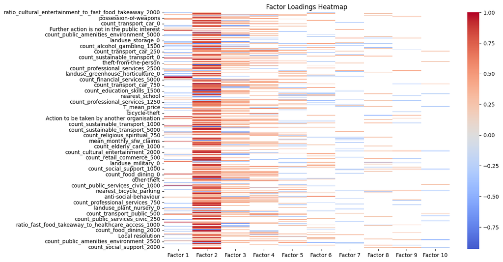

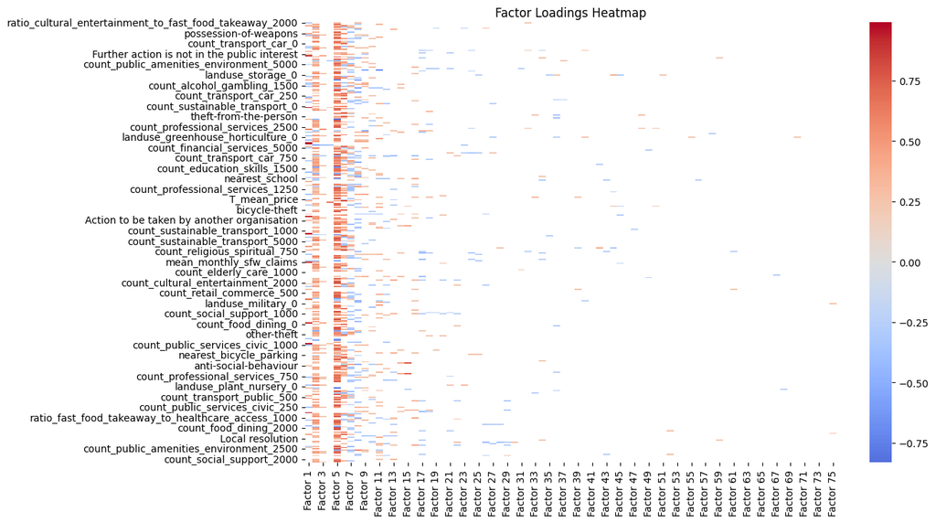

```python
# Factor loadings
for loadings in [loadings_10, loadings_75]:
    threshold = 0.2
    loadings_masked = loadings.where(loadings.abs() >= threshold)

    # Heatmap
    plt.figure(figsize=(12, 8))
    sns.heatmap(loadings_masked, cmap='coolwarm', center=0)
    plt.title("Factor Loadings Heatmap")
    plt.show()
```

Immediately, it can be seen that Factor 2 holds the majority of the datasets features which if the first Ridge and Elastic Net SLX models mentioned above are recalled, is a dropped feature. Meaning, the majority of the datasets features were not used by those models. Subsequent factors have constantly reduced number of feature loadings.

Factor 3 is checked in more detail since those models made use of it the most beyond Factor 1 as well as including its spatially weighted version.

```python
loadings_10.sort_values(by='Factor 3', ascending=False).head(30)
```

|  | Factor 1 | Factor 2 | Factor 3 | Factor 4 | Factor 5 | Factor 6 | Factor 7 | Factor 8 | Factor 9 | Factor 10 |
| --- | --- | --- | --- | --- | --- | --- | --- | --- | --- | --- |
| count_transport_car_750 | -0.051952 | 0.726831 | 0.502651 | 0.349159 | -0.112600 | -0.082735 | -0.057356 | 0.046982 | 0.105938 | 0.061810 |
| count_alcohol_gambling_500 | -0.092092 | 0.682511 | 0.499794 | 0.370363 | -0.143134 | 0.002326 | 0.004397 | 0.092805 | 0.105932 | 0.176606 |
| count_transport_car_500 | -0.069503 | 0.641130 | 0.499690 | 0.453576 | -0.031998 | -0.032007 | -0.010243 | 0.088908 | 0.142157 | 0.127639 |
| count_alcohol_gambling_750 | -0.064079 | 0.769543 | 0.492069 | 0.278897 | -0.189039 | -0.001459 | -0.016830 | 0.072588 | 0.051653 | 0.122583 |
| count_alcohol_gambling_250 | -0.076263 | 0.615558 | 0.486723 | 0.426703 | -0.067848 | 0.041291 | 0.029301 | 0.071078 | 0.081708 | 0.154078 |
| count_food_dining_500 | -0.036246 | 0.685783 | 0.484975 | 0.443747 | -0.097005 | 0.014869 | -0.009122 | 0.099202 | 0.180328 | 0.122482 |
| count_transport_car_250 | -0.076016 | 0.535890 | 0.482326 | 0.522626 | 0.047953 | 0.024640 | 0.054290 | 0.115157 | 0.139804 | 0.164349 |
| count_food_dining_250 | -0.074219 | 0.583501 | 0.476058 | 0.549186 | 0.030895 | 0.079112 | 0.067879 | 0.117822 | 0.146614 | 0.124118 |
| count_transport_public_500 | -0.213058 | 0.641340 | 0.472218 | 0.275691 | -0.111758 | -0.179206 | 0.150915 | 0.031864 | 0.024451 | 0.277420 |
| count_transport_car_1000 | -0.051699 | 0.802428 | 0.470442 | 0.224750 | -0.145444 | -0.111912 | -0.091289 | -0.017154 | 0.044661 | -0.031050 |
| count_transport_public_750 | -0.217373 | 0.720300 | 0.470383 | 0.168604 | -0.168887 | -0.211844 | 0.128587 | 0.007823 | -0.010638 | 0.215108 |
| count_food_dining_750 | -0.026217 | 0.765730 | 0.468844 | 0.341875 | -0.151455 | -0.021965 | -0.053579 | 0.066795 | 0.144312 | 0.059172 |
| count_alcohol_gambling_1000 | -0.067561 | 0.818654 | 0.458053 | 0.169865 | -0.216159 | 0.000703 | -0.019716 | 0.037162 | -0.014181 | 0.053048 |
| count_transport_public_250 | -0.192232 | 0.557797 | 0.455577 | 0.379643 | 0.006529 | -0.102803 | 0.205498 | 0.043475 | 0.000393 | 0.264198 |
| bicycle-theft | -0.053088 | 0.579298 | 0.454708 | 0.560851 | 0.169109 | 0.055566 | 0.124346 | 0.021074 | 0.011950 | 0.099241 |
| count_cultural_entertainment_500 | -0.138496 | 0.728475 | 0.448325 | 0.174285 | -0.103087 | -0.109750 | 0.132865 | 0.007668 | 0.026554 | 0.143363 |
| count_professional_services_1000 | -0.179373 | 0.693208 | 0.447425 | 0.055940 | -0.213015 | -0.253518 | 0.124838 | -0.061072 | -0.066384 | 0.134514 |
| count_transport_public_1000 | -0.218521 | 0.777166 | 0.445187 | 0.076709 | -0.165145 | -0.216995 | 0.126653 | -0.035842 | -0.065440 | 0.123436 |
| count_cultural_entertainment_750 | -0.147135 | 0.773966 | 0.439715 | 0.095319 | -0.132632 | -0.160783 | 0.153640 | -0.012549 | -0.033996 | 0.147089 |
| nearest_bar | 0.225654 | -0.801860 | 0.438876 | -0.074330 | 0.131042 | -0.136336 | -0.047628 | 0.094594 | -0.013537 | -0.082364 |
| count_education_skills_500 | -0.032602 | 0.574233 | 0.433494 | 0.281960 | 0.064143 | -0.014131 | -0.175941 | 0.039971 | -0.074281 | -0.078032 |
| count_food_dining_1000 | -0.022684 | 0.838099 | 0.433426 | 0.214115 | -0.183027 | -0.043029 | -0.071166 | 0.015262 | 0.077206 | -0.012307 |
| count_cultural_entertainment_250 | -0.141624 | 0.613011 | 0.432713 | 0.268896 | -0.013239 | -0.067828 | 0.206584 | 0.047648 | -0.028117 | 0.169234 |
| count_sustainable_transport_250 | -0.124654 | 0.736585 | 0.431799 | 0.365985 | 0.081304 | -0.011921 | 0.046199 | 0.080142 | 0.088002 | 0.139227 |
| count_professional_services_750 | -0.177251 | 0.623441 | 0.431369 | 0.099453 | -0.187461 | -0.255621 | 0.129240 | -0.072429 | -0.037301 | 0.180067 |
| count_sustainable_transport_500 | -0.134258 | 0.814591 | 0.431233 | 0.279704 | -0.005876 | -0.050627 | 0.011197 | 0.074242 | 0.086231 | 0.115341 |
| count_cultural_entertainment_1000 | -0.146640 | 0.828696 | 0.429742 | 0.045653 | -0.121805 | -0.145493 | 0.140837 | -0.057604 | -0.042024 | 0.065399 |
| count_education_skills_750 | -0.051469 | 0.669016 | 0.424262 | 0.246613 | 0.029730 | -0.016795 | -0.193416 | 0.019003 | -0.070758 | -0.125529 |
| count_transport_car_1250 | -0.057944 | 0.859286 | 0.423309 | 0.095053 | -0.136277 | -0.104036 | -0.080858 | -0.066931 | -0.019416 | -0.094678 |
| count_public_amenities_environment_250 | -0.114124 | 0.727184 | 0.419703 | 0.327506 | 0.023633 | -0.000251 | 0.045522 | 0.214280 | -0.035999 | 0.133484 |

Bar but one, these are all OSM features but what is perhaps more interesting, they have higher loadings on Factor than 3. This is somewhat perplexing and could bear looking into further, but being mindfull of the this notebook's purpose, maybe thats best left as further work.

## Summary

In summary this notebook shows a few things:

1. Simple regression models outperform SLX
2. Lasso outperfrorms Ridge
3. UC features are highly predictive and are often dominant in regression models.

On 1:

In most cases simple regression models either outperformed their spatial counterparts and when SLX did do well, spatially weighted features were often regularised out. Though there were two models seen at the end: Ridge SLX with an alpha of 10 and Elastic Net SLX with an alpha of 0.1, both being on teh FA 10 dataset. Apart from doubts on overfitting, model stability or any other case beyond the metrics of this notebook, the case can be made that non-spatial regression models work better. This is likely due to many features already implicitly holding spatial relationships, reducing the marginal benefit of adding spatial lags.

On 2:

Lasso regularised models perform best on almost all metrics. After some coefficient analysis it is seen that Lasso does best when shrinking the scaled dataset of roughly 400 features down to about 10 which suggests that the underlying relationship is sparse, with predictive power being concentrated in a small subset of features. This is in part likely due to high multicolinierity. In this sense, many of the original variables likely act as proxies for a smaller number of latent factors. Lasso effectively reduces down to just these latent factors whereas Ridge attempts to do the same whilst retaining some noise and redundancy.

On 3:

The bets performing models and even some less so select a UC feature or a reduced feature which is highly loaded with a UC feature with a coefficient which is an order of magnitude above all other coefficients. In thi sense, UC features are disproportionately predictive compared to other features. This kind of reliance may warrant further investigation and could raise issues of robustness if that one feature becomes unavailable.

Next Steps:

1. Repeat experiments on tree based models with the extended dataset.
2. Perform modelling experiments with a dataset omitting UC features. Observe how this impacts performance, coeffs and weather it gives some models more relevance.